# An Application of Tidyverse in Data Analysis

A sample data tidying and analysis of the Goldenrod Gall Fly Larvae data from Bio 314: Ecology and Evolution at Georgetown College.

Ben Peterson https://runnaboibp.github.io/fleetGeekBlog (Georgetown College)https://georgetowncollege.edu  
2019-04-30

## Introduction

The Goldenrod Gall Fly (GF) is a species of fly that lays its eggs in the stem of the goldenrod plant. The larvae hatch and secrete a hormone that causes the stem to grow a woody bulge that the larvae use as shelter and food throughout the winter. The life of a gall fly larva is far from safe, however, as they have a number of predators that attack the galls. The predators we focus on in this experiment are the chickadee (C), the downy woodpecker (WP), and a species of parasitoid wasp (EG). The Bio 314 lab class traveled to a field next to Lane’s Run stream in Scott County and collected a sample of 428 galls, taking measurements on how high the gall was from the ground (gallHeight), the gall diameter (gallDiameter), the diameter of the hole in the gall if there was one (holeDiameter), and whether the gall was away from treeline by the water (>3 feet) or near it (<= 3 feet). Based on the diameter of the hole, the lab groups made conclusions on what caused the hole (expectedCause). This data was gathered into a Microsoft Excel Document and made available to me for this data analysis project.

## Pre-Analysis Tidying

The **tidyverse** package came in handy for the dataset, because the pipe (%>%) operator and the `rename()` and `select()` functions from **dplyr** were used to create legal varaible names and select the variables desired in this data analysis. The ID column also did not have uniform identifier names, so a simple assignment to the set of numbers from 1 to 428 (the number of galls in the sample) fixed the naming issue.

## Methods

For this analysis, a linear model was used to see if there is a correlation between the height of the gall and the hole size, and another was used to determine whether there was a correlation between gall diameter and hole size. The results of these led to a third question–whether gall diameter could predict the expected cause of gall hole.

The variables used for this analysis were:

- gallHeight - the height of the gall from the ground (in cm)
- gallDiameter - the diameter of the gall (in mm)
- holeDiameter - the diameter of the hole found in the gall (in mm)
- expectedCause - the expected cause of the hole found in the gall

## Results

### Gall Height versus Hole Diameter

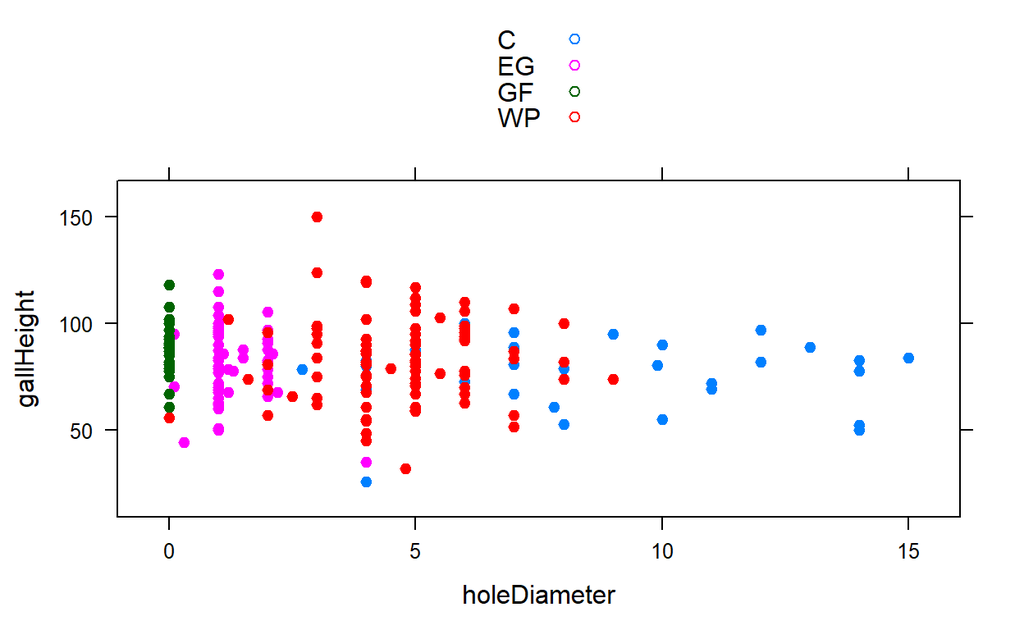

```
    Linear Regression

Correlation coefficient r =  0.03133

Equation of Regression Line:

     gallHeight = 79.4104 + 0.1941 * holeDiameter

Residual Standard Error:    s   = 18.9827
R^2 (unadjusted):       R^2 = 0.001
```

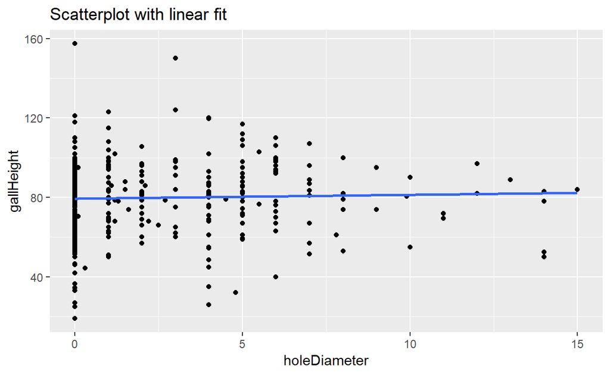

The linear model gave a correlation coefficient of r=0.03133. Remember that r always falls between -1 and 1, with the sign of r indicating positive/negative correlation and the magnitude of r showing the strength of correlation. Here, with r only being 0.03, it backs up the inference that there is not a very strong correlation between gall height and hole diameter.

One theory that can be drawn from this is that predators do not tend to show a preference in the height of galls that they attack.

### Gall Diameter versus Hole Diameter

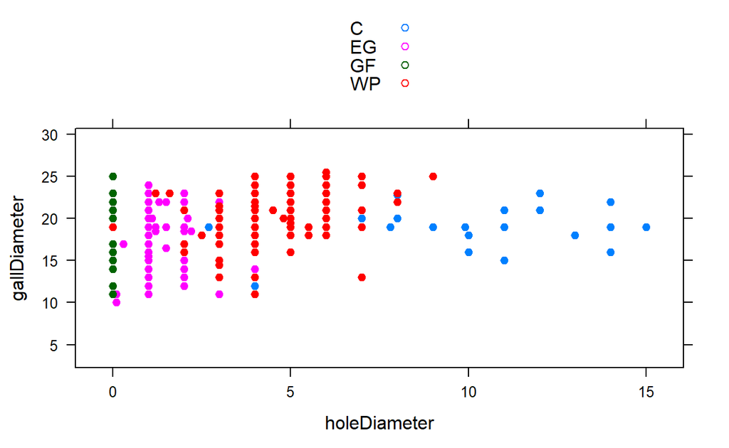

```
    Linear Regression

Correlation coefficient r =  0.254

Equation of Regression Line:

     gallDiameter = 17.7408 + 0.3113 * holeDiameter

Residual Standard Error:    s   = 3.6296
R^2 (unadjusted):       R^2 = 0.0645
```

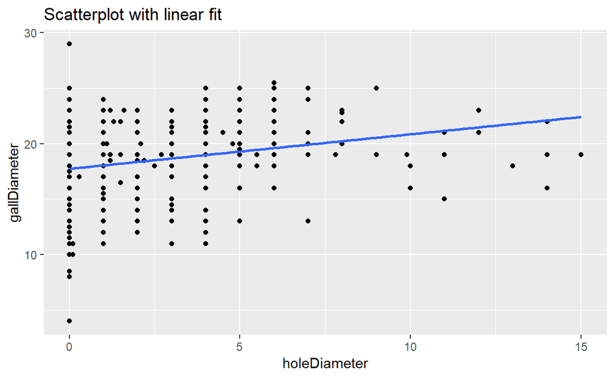

This time, a correlation coefficient of r = 0.254 was obtained. According to this model, there was a bit stronger of a correlation between the diameter of the gall and the diameter of the hole. However, the correlation is still not a very strong one. This correlation does make sense, as you would expect birds (which leave the larger holes) to go after larger sized galls because they are easier to spot. And the smaller galls tend to be attacked by parasitoid wasps, or have successful gall fly larvae emerge from it, which is shown by the scatterplot above.

### Gall Diameter versus Expected Cause

The correlation between gall diameter and hole diameter led to the question of whether there was a relationship between the gall’s diameter and the expected cause of gall hole.

#### Numerical Analysis

First, the data was analyzed using the `favstats()` function from the **mosaic** package to find the spread of diameters for each group:

```
  expectedCause min Q1 median   Q3  max     mean       sd   n missing
1             C  12 18     20 21.5 25.0 19.53333 2.848576  39       0
2            EG  10 15     18 20.0 24.0 17.39855 3.802650  69       0
3            GF  11 17     19 21.0 25.0 18.66667 3.812261  21       0
4            WP  11 18     20 22.0 25.5 20.00455 2.933120 110       0
```

As you can see, the mean diameter of bird attacked (WP, C) galls, 19.75 ((20+19.5)/2), is higher than the mean diameter of non-bird attacked (GF, EG) galls, 18.5 ((19+18)/2). This can be analyzed using a density plot to support this difference of means claim.

#### Graphical Analysis

Next, the data was plotted using a density plot to see the gall diameters by expected cause:

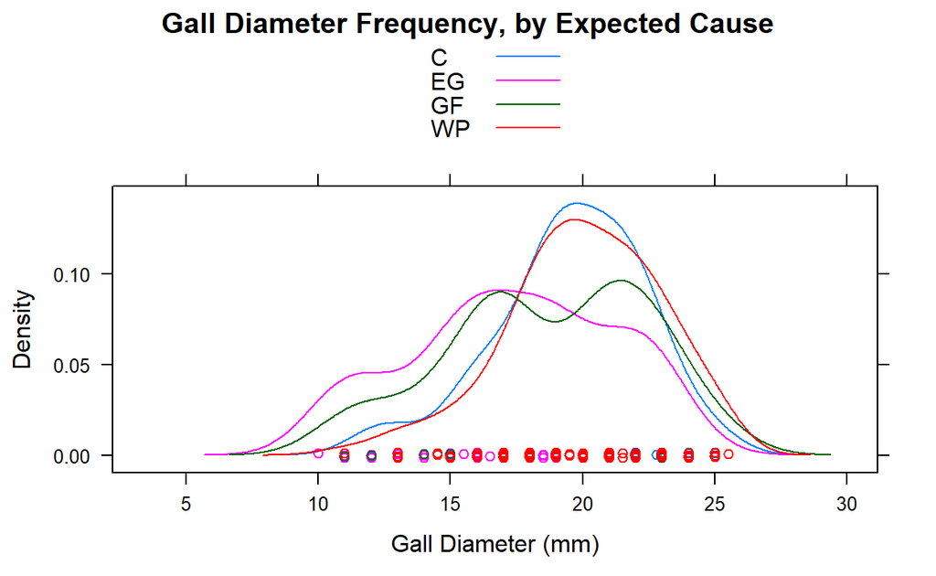

The graph shows what was concluded from the numerical analysis, that the mean diameters of galls attacked by birds is higher than the mean diameters of galls attacked by wasps or that had successful gall fly larvae.

### Statistical Significance

An ANOVA (analysis of variance) was used to determine whether there was a statistically significant difference in the means of the groups. The overall group mean $\mu$ can be found using `favstats()`:

```
 min Q1 median Q3 max     mean       sd   n missing
   4 16     19 21  29 18.46143 3.748032 407      21
```

Here we have $\mu$ = 18.46.

$H_0$: $\mu_1$ - $\mu_2$ = 0

$H_a$: $\mu_1$ - $\mu_2$ $\neq$ 0

Here, the `lm()` function and the `anova()` function was used to calculate the significance.

```
Call:
lm(formula = gallDiameter ~ expectedCause, data = studentGallData)

Residuals:
    Min      1Q  Median      3Q     Max
-9.0045 -2.0045 -0.0045  2.3333  6.6014

Coefficients:
                Estimate Std. Error t value Pr(>|t|)
(Intercept)      19.5333     0.5244  37.251   <2e-16 ***
expectedCauseEG  -2.1348     0.6560  -3.254   0.0013 **
expectedCauseGF  -0.8667     0.8863  -0.978   0.3292
expectedCauseWP   0.4712     0.6103   0.772   0.4408
---
Signif. codes:  0 '***' 0.001 '**' 0.01 '*' 0.05 '.' 0.1 ' ' 1

Residual standard error: 3.275 on 235 degrees of freedom
  (189 observations deleted due to missingness)
Multiple R-squared:  0.1066,    Adjusted R-squared:  0.09516
F-statistic: 9.344 on 3 and 235 DF,  p-value: 7.362e-06
```

```
Analysis of Variance Table

Response: gallDiameter
               Df  Sum Sq Mean Sq F value    Pr(>F)
expectedCause   3  300.59 100.197  9.3436 7.362e-06 ***
Residuals     235 2520.05  10.724
---
Signif. codes:  0 '***' 0.001 '**' 0.01 '*' 0.05 '.' 0.1 ' ' 1
```

## Conclusion

The analysis done on the gall fly larva data determined that there is no significant evidence that gall height plays any factor in the predation preferences of birds and wasps. The linear regression model for gall diameter showed a slight correlation between gall diameter and hole diameter, which led to the question of if gall diameter could be used to predict the expected cause of attack. An ANOVA test and linear model summary were used to determine the significance of the difference in mean between the groups and the overall gall mean. This lead to the conclusion that gall diameter does indeed play a factor in the expected cause of attack. Likely, the larger galls are targeted more by birds, as we saw in the grahical analysis, because they are easier to spot by birds.